# Week seven solutions

Just two visualisations in this week’s task. But first we have to load our packages, load our data and then merge the **degrees** dataset with the **h_and_w** one.

In the code below, I load the packages and data you used in the lab.

```r
library(tidyverse)
library(sf)
westminster <- read_sf(dsn = ".", layer = "westminster_const_region")
housing <- read.csv("housing.csv")
h_and_w <- inner_join(westminster, housing, by = "CODE")
```

Next, I’m going to load the **degrees** dataset.

```r
degrees <- read_csv("degrees.csv")
```

Finally, I’ll use the inner_join function to merge degrees with h_and_w. I’m going to call the new dataset d_and_w. Remember, the inner_join function uses the following format: - Name your new dataset, in this example it is d_and_w - Use the <- operator to tell R we are creating a new object, which will consist of what appears on the right of this arrow - Open the inner_join function - Specify the first dataset to merge, which is h_and_w in this example - Specify the second dataset to merge, which is degrees in this example - Specify the id variable, which is the variable both datasets have in common, so they will merge where the observations in this variable match; in this example the id variable is CODE, which is a unique code for each constituency

```r
d_and_w <- inner_join(h_and_w, degrees, by = "CODE")
```

## Map 1

Question 1 asks us to produce, “a map of the fraction of adults in each parliamentary constituency with degrees, treating the DEGREES variable as continuous”.

Below I’ve produced the first graph. As we’re using a continuous variable for the fill, I’ve used the function **scale_fill_viridis_c** for the colour scale.

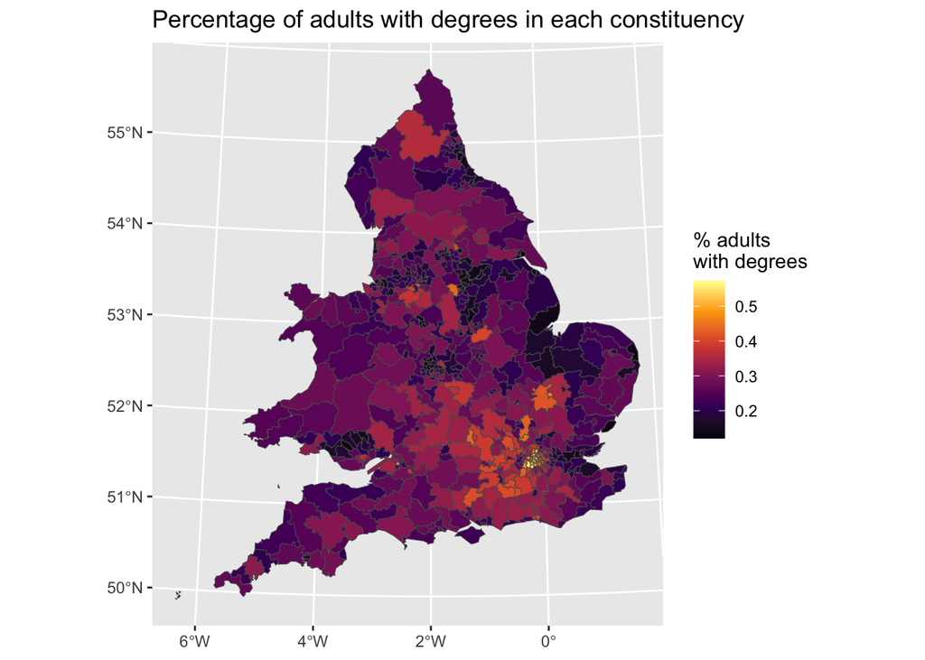

```r
ggplot(data = d_and_w) +
  aes(fill = DEGREES) +
  geom_sf() +
  scale_fill_viridis_c(option = "B") +
  labs(
    title = "Percentage of adults with degrees in each constituency",
    fill = "% adults\nwith degrees"
  )
```